**IMPA - Ciência de Dados Aplicada - Exercício 1**

*por Kizzy Terra*

# Análise dos dados de Desflorestamento nos municípios do Amazonas

## Introdução

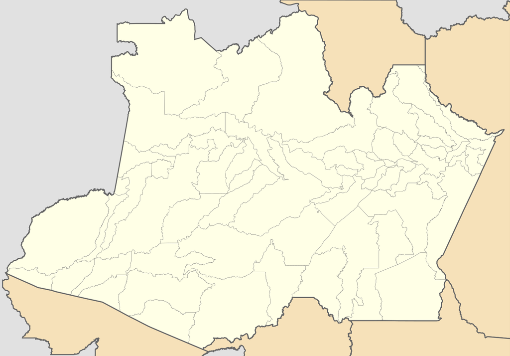

```python
from IPython.display import Image
local_image = Image('./1600px-Brazil_Amazonas_location_map.png')
display(local_image)
```

Esse trabalho motiva-se pelo crescente número de notícias recentes acerca do desflorestamento da Amazônia. Nas últimas semanas essa pauta esteve no centro do debate nacional.

[figure not shown]

```python
g1_local_image = Image('./noticia-g1.png')
display(g1_local_image)
```

Carregamento e pré-processamento dos dados a serem analisados:

```python
#importação de pacotes
import matplotlib.pyplot as plt
import pandas as pd
import numpy as np

#pacote para plotar no mapa
import mplleaflet
```

```python
#Importando dados do ibge de estados e municípios
amazonas2014_df = pd.read_csv("amazonas.csv")
estados_df = pd.read_csv("estados.csv")
municipios_df = pd.read_csv("municipios.csv")
```

Começaremos olhando a forma dos DataFrames criados:

```python
amazonas2014_df
```

|  | Municípios | Agricultura Anual | Área não Observada | Área Urbana | Desflorestamento 2014 | Floresta | Hidrografia | Mineração | Mosaico de Ocupações | Não Floresta | Outros | Pasto com Solo Exposto | Pasto Limpo | Pasto Sujo | Reflorestamento | Regeneração com Pasto | Vegetação Secundária | Total Geral |
| --- | --- | --- | --- | --- | --- | --- | --- | --- | --- | --- | --- | --- | --- | --- | --- | --- | --- | --- |
| 0 | Alvaraes | NaN | 0.07 | 1.90 | 2.75 | 5,415.56 | 133.87 | NaN | 101.08 | 43.26 | 5.36 | NaN | 2.92 | 1.02 | NaN | 5.13 | 198.55 | 5,911.46 |
| 1 | Amatura | NaN | NaN | 2.05 | 0.36 | 4,220.22 | 209.41 | NaN | 15.87 | 216.55 | 3.76 | NaN | 4.03 | NaN | NaN | 11.44 | 71.74 | 4,755.42 |
| 2 | Anama | NaN | 0.86 | 0.89 | 0.44 | 2,001.85 | 229.30 | NaN | 6.90 | 34.81 | 13.11 | NaN | 2.02 | 0.87 | NaN | NaN | 160.61 | 2,451.66 |
| 3 | Anori | NaN | 0.15 | 2.77 | 0.59 | 4,646.53 | 436.07 | NaN | 17.12 | 636.01 | 4.70 | NaN | 8.05 | 0.52 | NaN | NaN | 41.98 | 5,794.49 |
| 4 | Apui | NaN | 6.71 | 5.91 | 80.19 | 51,396.43 | 213.50 | NaN | 8.76 | 622.87 | 7.18 | NaN | 812.61 | 329.85 | NaN | 208.13 | 546.18 | 54,238.32 |
| 5 | Atalaia do Norte | NaN | 10.99 | 2.99 | 0.70 | 75,692.73 | 396.05 | NaN | 12.84 | 15.57 | 2.18 | NaN | NaN | NaN | NaN | 11.28 | 187.54 | 76,332.86 |
| 6 | Autazes | NaN | 24.24 | 4.58 | 8.35 | 4,864.85 | 1,124.54 | NaN | 137.82 | 468.41 | 139.76 | NaN | 248.64 | 38.05 | NaN | 90.23 | 451.25 | 7,600.72 |
| 7 | Barcelos | NaN | 0.23 | 4.27 | 1.91 | 100,948.88 | 4,464.66 | 0.01 | 25.66 | 16,837.56 | 5.68 | NaN | 1.32 | 0.10 | NaN | 4.84 | 146.95 | 122,442.07 |
| 8 | Barreirinha | NaN | 65.07 | 6.40 | 4.46 | 3,605.04 | 975.48 | NaN | 84.83 | 408.36 | 59.38 | NaN | 124.85 | 14.63 | NaN | 55.33 | 347.03 | 5,750.86 |
| 9 | Benjamin Constant | NaN | 29.04 | 10.47 | 0.31 | 8,411.90 | 200.93 | NaN | 35.75 | 0.04 | 3.35 | NaN | 0.75 | 1.17 | NaN | 0.88 | 97.10 | 8,791.69 |
| 10 | Beruri | NaN | 1.04 | 3.44 | 2.29 | 15,584.50 | 577.91 | NaN | 14.26 | 873.43 | 9.18 | NaN | 11.06 | 0.68 | NaN | 0.08 | 173.09 | 17,250.95 |
| 11 | Boa Vista do Ramos | NaN | 11.70 | 1.83 | 1.01 | 1,119.42 | 413.95 | NaN | 34.48 | 851.93 | 15.04 | NaN | 10.57 | 2.85 | NaN | 28.90 | 91.61 | 2,583.30 |
| 12 | Boca do Acre | NaN | 17.96 | 5.49 | 71.96 | 19,542.90 | 143.16 | 1.90 | 47.57 | 61.64 | 17.49 | NaN | 1,040.03 | 315.60 | NaN | 241.86 | 438.78 | 21,946.33 |
| 13 | Borba | NaN | 3.15 | 14.60 | 1.44 | 41,286.75 | 1,867.25 | NaN | 89.50 | 583.91 | 35.41 | NaN | 14.01 | 3.94 | NaN | 20.15 | 322.93 | 44,243.03 |
| 14 | Caapiranga | NaN | 9.68 | 2.89 | 0.76 | 8,619.87 | 432.67 | 0.01 | 11.09 | 181.34 | 42.79 | NaN | 5.42 | 0.25 | NaN | 9.71 | 144.23 | 9,460.72 |
| 15 | Canutama | NaN | 5.97 | 3.30 | 16.62 | 27,529.67 | 295.98 | NaN | 38.65 | 972.93 | 18.98 | 0.85 | 161.26 | 236.60 | NaN | 168.53 | 364.64 | 29,813.98 |
| 16 | Carauari | NaN | 0.15 | 5.93 | 1.05 | 25,084.19 | 391.37 | NaN | 27.54 | 12.81 | 10.37 | NaN | 39.81 | 3.90 | NaN | 17.94 | 175.89 | 25,770.94 |
| 17 | Careiro | NaN | 67.07 | 4.59 | 0.53 | 4,593.12 | 422.06 | NaN | 77.71 | 72.40 | 204.25 | NaN | 113.83 | 17.29 | NaN | 69.25 | 449.79 | 6,091.88 |
| 18 | Careiro da Varzea | NaN | 23.89 | 0.28 | 2.71 | 766.21 | 649.15 | NaN | 8.61 | 723.13 | 129.07 | NaN | 120.12 | 13.96 | NaN | 86.45 | 105.43 | 2,629.00 |
| 19 | Coari | NaN | 0.37 | 12.90 | 3.25 | 53,623.67 | 2,746.07 | NaN | 85.46 | 811.85 | 21.69 | NaN | 7.23 | 0.49 | NaN | 0.56 | 605.20 | 57,918.73 |
| 20 | Codajas | 0.02 | 0.00 | 2.51 | 2.98 | 16,314.98 | 1,457.35 | NaN | 12.39 | 688.14 | 6.84 | NaN | 8.04 | 0.42 | NaN | NaN | 219.21 | 18,712.88 |
| 21 | Eirunepe | NaN | 1.26 | 9.89 | 2.40 | 14,304.15 | 181.76 | NaN | 57.82 | 165.10 | 6.42 | NaN | 76.41 | 10.03 | NaN | 16.53 | 179.62 | 15,011.37 |
| 22 | Envira | NaN | 7.02 | 5.01 | 7.45 | 7,172.22 | 63.28 | NaN | 24.09 | 0.11 | 3.94 | NaN | 75.67 | 24.54 | NaN | 25.21 | 93.94 | 7,502.48 |
| 23 | Fonte Boa | NaN | NaN | 4.83 | 1.00 | 11,049.62 | 815.39 | NaN | 8.17 | 150.43 | 5.33 | NaN | 1.25 | 0.48 | NaN | 4.08 | 68.71 | 12,109.28 |
| 24 | Guajara | NaN | 0.74 | 2.66 | 1.12 | 6,915.13 | 10.46 | NaN | 30.59 | 197.14 | 4.91 | NaN | 166.98 | 51.86 | NaN | 33.59 | 163.16 | 7,578.34 |
| 25 | Humaita | 0.02 | 10.24 | 2.08 | 13.95 | 28,496.19 | 783.77 | NaN | 73.40 | 3,087.09 | 18.43 | NaN | 123.49 | 37.74 | NaN | 64.73 | 356.43 | 33,067.55 |
| 26 | Ipixuna | NaN | 0.46 | 2.89 | 1.07 | 11,692.44 | 69.08 | NaN | 19.75 | 64.38 | 2.28 | NaN | 45.68 | 25.90 | NaN | 16.96 | 103.48 | 12,044.38 |
| 27 | Iranduba | 0.30 | 1.89 | 33.64 | 2.24 | 1,295.24 | 322.64 | 0.39 | 99.93 | 132.02 | 43.20 | 0.07 | 35.40 | 9.29 | NaN | 36.15 | 202.81 | 2,215.20 |
| 28 | Itacoatiara | 0.00 | 151.70 | 16.14 | 5.54 | 4,644.79 | 1,770.43 | 0.03 | 252.06 | 861.47 | 182.12 | 0.33 | 245.05 | 23.03 | NaN | 54.02 | 689.04 | 8,895.72 |
| 29 | Itamarati | NaN | 0.49 | 1.74 | 2.45 | 24,866.50 | 283.51 | NaN | 19.06 | 3.01 | 3.90 | NaN | 14.24 | 0.29 | NaN | 4.23 | 80.04 | 25,279.46 |
| ... | ... | ... | ... | ... | ... | ... | ... | ... | ... | ... | ... | ... | ... | ... | ... | ... | ... | ... |
| 32 | Jurua | NaN | 1.81 | 2.58 | 1.81 | 18,400.39 | 713.44 | NaN | 16.12 | 140.08 | 5.38 | NaN | 3.03 | 1.50 | NaN | 4.22 | 109.45 | 19,399.80 |
| 33 | Jutai | NaN | 0.10 | 3.63 | 1.61 | 68,099.67 | 1,126.45 | NaN | 11.38 | 96.79 | 14.51 | NaN | 13.55 | 0.98 | NaN | 5.74 | 177.99 | 69,552.40 |
| 34 | Labrea | NaN | 23.97 | 11.94 | 130.13 | 62,531.60 | 443.40 | 2.25 | 33.18 | 1,765.98 | 17.26 | NaN | 2,152.30 | 160.58 | NaN | 151.93 | 808.59 | 68,233.10 |
| 35 | Manacapuru | NaN | 15.64 | 14.37 | 3.04 | 4,332.40 | 1,459.87 | 0.86 | 102.85 | 798.49 | 189.59 | NaN | 55.82 | 8.25 | NaN | 25.91 | 320.51 | 7,327.60 |
| 36 | Manaquiri | NaN | 17.31 | 1.51 | 0.14 | 3,088.33 | 341.04 | NaN | 35.82 | 105.94 | 122.31 | NaN | 27.09 | 2.10 | NaN | 6.97 | 225.88 | 3,974.45 |
| 37 | Manaus | 78.19 | 10.81 | 343.40 | 2.11 | 8,612.34 | 1,580.05 | 16.89 | 189.81 | 2.44 | 38.47 | NaN | 38.14 | 11.65 | NaN | 21.40 | 458.73 | 11,404.42 |
| 38 | Manicore | 0.04 | 14.73 | 12.43 | 29.78 | 41,617.44 | 825.18 | NaN | 98.19 | 4,135.80 | 100.05 | 0.09 | 509.92 | 109.89 | NaN | 102.13 | 725.68 | 48,281.37 |
| 39 | Maraa | NaN | NaN | 2.02 | 1.68 | 14,400.01 | 1,799.86 | NaN | 21.59 | 592.76 | 1.50 | NaN | 2.57 | 0.17 | NaN | 6.13 | 77.42 | 16,905.71 |
| 40 | Maues | 2.55 | 10.27 | 6.41 | 13.87 | 36,472.52 | 1,379.53 | 6.70 | 208.79 | 867.52 | 57.10 | 0.01 | 99.02 | 46.43 | NaN | 32.87 | 767.39 | 39,970.97 |
| 41 | Nhamunda | NaN | 51.31 | 1.22 | 2.32 | 12,140.99 | 1,109.11 | NaN | 62.68 | 342.90 | 15.53 | NaN | 68.65 | 19.34 | NaN | 20.91 | 238.43 | 14,073.40 |
| 42 | Nova Olinda do Norte | NaN | 0.63 | 4.03 | 1.14 | 4,473.84 | 475.04 | NaN | 83.87 | 281.93 | 26.77 | NaN | 24.61 | 4.39 | NaN | 6.83 | 224.66 | 5,607.75 |
| 43 | Novo Airao | NaN | 0.15 | 3.73 | 0.86 | 36,114.27 | 1,327.87 | NaN | 15.19 | 210.03 | 10.44 | NaN | 7.36 | 1.38 | NaN | 4.59 | 66.02 | 37,761.89 |
| 44 | Novo Aripuana | NaN | 26.10 | 5.58 | 22.55 | 37,840.85 | 766.01 | 10.85 | 23.54 | 1,614.89 | 42.87 | NaN | 296.89 | 62.84 | NaN | 50.26 | 425.68 | 41,188.92 |
| 45 | Parintins | NaN | 76.59 | 2.62 | 4.24 | 1,568.15 | 2,378.95 | NaN | 114.56 | 1,056.57 | 19.95 | NaN | 163.48 | 44.84 | NaN | 79.20 | 438.31 | 5,947.48 |
| 46 | Pauini | NaN | 1.42 | 1.82 | 9.47 | 41,087.97 | 257.55 | NaN | 25.12 | 23.42 | 5.19 | NaN | 69.08 | 12.72 | NaN | 9.05 | 107.74 | 41,610.56 |
| 47 | Presidente Figueiredo | 43.24 | 108.70 | 11.63 | 6.21 | 21,281.25 | 3,408.07 | 1.48 | 61.46 | 0.98 | 13.44 | 0.02 | 60.55 | 39.79 | 3.01 | 31.84 | 354.03 | 25,425.71 |
| 48 | Rio Preto da Eva | 0.83 | 14.53 | 15.91 | 1.11 | 5,231.90 | 16.78 | 0.88 | 132.48 | NaN | 5.22 | NaN | 34.21 | 6.54 | 6.19 | 17.86 | 326.13 | 5,810.56 |
| 49 | Santa Isabel do Rio Negro | NaN | 2.38 | 3.04 | 0.91 | 61,070.69 | 622.20 | NaN | 31.59 | 939.92 | 6.60 | NaN | 4.36 | 0.74 | NaN | 3.85 | 151.05 | 62,837.32 |
| 50 | Santo Antonio do Ica | NaN | 0.04 | 7.88 | 0.80 | 11,649.37 | 439.80 | NaN | 33.82 | 89.28 | 4.78 | NaN | 3.11 | 2.32 | NaN | 4.62 | 73.77 | 12,309.60 |
| 51 | Sao Gabriel da Cachoeira | NaN | 45.37 | 20.77 | 1.82 | 106,052.38 | 1,472.95 | NaN | 188.04 | 477.72 | 13.79 | NaN | 3.14 | 1.03 | NaN | 17.31 | 857.83 | 109,152.15 |
| 52 | Sao Paulo de Olivenca | NaN | 1.47 | 7.09 | 1.00 | 18,927.02 | 568.89 | NaN | 41.42 | 82.86 | 7.92 | NaN | 4.23 | 5.86 | NaN | 10.57 | 90.45 | 19,748.77 |
| 53 | Sao Sebastiao do Uatuma | NaN | 12.82 | 3.28 | 3.78 | 9,830.42 | 638.47 | 0.14 | 27.79 | 65.44 | 3.49 | NaN | 60.60 | 7.31 | NaN | 8.61 | 77.24 | 10,739.39 |
| 54 | Silves | NaN | 58.71 | 2.01 | 0.54 | 2,588.26 | 626.26 | NaN | 53.68 | 133.09 | 67.18 | NaN | 31.00 | 1.04 | NaN | 16.53 | 168.40 | 3,746.72 |
| 55 | Tabatinga | NaN | 5.46 | 15.95 | 1.72 | 3,013.65 | 53.57 | NaN | 38.30 | 1.18 | 8.35 | NaN | 0.77 | 8.38 | NaN | 0.08 | 74.91 | 3,222.33 |
| 56 | Tapaua | NaN | 0.69 | 3.32 | 2.99 | 85,391.65 | 1,488.19 | NaN | 25.96 | 2,124.44 | 7.94 | 0.07 | 21.73 | 6.88 | NaN | 9.07 | 242.40 | 89,325.33 |
| 57 | Tefe | 0.00 | 0.35 | 11.60 | 8.79 | 22,189.29 | 719.59 | NaN | 147.59 | 163.90 | 7.34 | NaN | 5.53 | 2.40 | NaN | 8.48 | 439.55 | 23,704.42 |
| 58 | Tonantins | NaN | NaN | 3.91 | 0.36 | 5,976.36 | 308.81 | NaN | 27.63 | 65.34 | 1.94 | NaN | 1.49 | 2.43 | NaN | 1.30 | 41.71 | 6,431.27 |
| 59 | Uarini | NaN | 0.21 | 2.45 | 3.46 | 9,466.29 | 433.31 | NaN | 84.81 | 99.22 | 1.26 | NaN | 0.42 | NaN | NaN | 3.72 | 149.20 | 10,244.35 |
| 60 | Urucara | NaN | 15.98 | 4.11 | 1.45 | 26,495.54 | 656.25 | 1.78 | 55.89 | 422.64 | 8.52 | NaN | 58.12 | 7.73 | NaN | 8.78 | 161.54 | 27,898.33 |
| 61 | Urucurituba | NaN | 3.49 | 2.63 | 0.62 | 130.20 | 1,002.16 | 0.03 | 13.84 | 1,686.88 | 8.54 | NaN | 15.76 | 4.08 | NaN | 0.61 | 40.67 | 2,909.51 |

62 rows × 18 columns

```python
estados_df.head()
```

|  | codigo_uf | uf | nome |
| --- | --- | --- | --- |
| 0 | 11 | RO | Rondônia |
| 1 | 12 | AC | Acre |
| 2 | 13 | AM | Amazonas |
| 3 | 14 | RR | Roraima |
| 4 | 15 | PA | Pará |

```python
municipios_df.head()
```

|  | codigo_ibge | nome | latitude | longitude | capital | codigo_uf |
| --- | --- | --- | --- | --- | --- | --- |
| 0 | 5200050 | Abadia de Goiás | -16.75730 | -49.4412 | 0 | 52 |
| 1 | 3100104 | Abadia dos Dourados | -18.48310 | -47.3916 | 0 | 31 |
| 2 | 5200100 | Abadiânia | -16.19700 | -48.7057 | 0 | 52 |
| 3 | 3100203 | Abaeté | -19.15510 | -45.4444 | 0 | 31 |
| 4 | 1500107 | Abaetetuba | -1.72183 | -48.8788 | 0 | 15 |

Após carregar os dados devemos associar as tabelas de estados e municípios e selecionar apenas os municípios do Amazonas:

```python
estados_df[estados_df.uf=='AM']
```

|  | codigo_uf | uf | nome |
| --- | --- | --- | --- |
| 2 | 13 | AM | Amazonas |

Criando um novo objeto DataFrame para armazenar os dados acerca dos municípios do Amazonas:

```python
municipiosAM_df = municipios_df[municipios_df.codigo_uf ==13]
```

```python
municipiosAM_df.head()
```

|  | codigo_ibge | nome | latitude | longitude | capital | codigo_uf |
| --- | --- | --- | --- | --- | --- | --- |
| 170 | 1300029 | Alvarães | -3.22727 | -64.8007 | 0 | 13 |
| 195 | 1300060 | Amaturá | -3.37455 | -68.2005 | 0 | 13 |
| 216 | 1300086 | Anamã | -3.56697 | -61.3963 | 0 | 13 |
| 252 | 1300102 | Anori | -3.74603 | -61.6575 | 0 | 13 |
| 286 | 1300144 | Apuí | -7.19409 | -59.8960 | 0 | 13 |

Note que nos dados provenientes da tabela *municipios.csv* o nome dos municípios estão todos acentuados, no entanto na tabela amazonas os nomes estão sem acento. Logo é necessario remover os acentos dos nomes da tabela *municipios.csv*.

```python
from unicodedata import normalize
# use esta funçao para remover acentos
def remove_acentos_python3(txt):
    return str(normalize('NFKD', txt).encode('ASCII', 'ignore'), 'utf-8')
```

```python
municipiosAM_df['nome'] = municipiosAM_df['nome'].apply(lambda nome: remove_acentos_python3(nome))
```

```python
municipiosAM_df.head()
```

|  | codigo_ibge | nome | latitude | longitude | capital | codigo_uf |
| --- | --- | --- | --- | --- | --- | --- |
| 170 | 1300029 | Alvaraes | -3.22727 | -64.8007 | 0 | 13 |
| 195 | 1300060 | Amatura | -3.37455 | -68.2005 | 0 | 13 |
| 216 | 1300086 | Anama | -3.56697 | -61.3963 | 0 | 13 |
| 252 | 1300102 | Anori | -3.74603 | -61.6575 | 0 | 13 |
| 286 | 1300144 | Apui | -7.19409 | -59.8960 | 0 | 13 |

Em seguida relacionamos as tabelas municipios e amazonas em um novo DataFrame:

```python
merged_df = pd.merge(amazonas2014_df, municipiosAM_df, how='left', left_on=['Municípios'], right_on=['nome'])
```

```python
merged_df.head()
```

|  | Municípios | Agricultura Anual | Área não Observada | Área Urbana | Desflorestamento 2014 | Floresta | Hidrografia | Mineração | Mosaico de Ocupações | Não Floresta | ... | Reflorestamento | Regeneração com Pasto | Vegetação Secundária | Total Geral | codigo_ibge | nome | latitude | longitude | capital | codigo_uf |
| --- | --- | --- | --- | --- | --- | --- | --- | --- | --- | --- | --- | --- | --- | --- | --- | --- | --- | --- | --- | --- | --- |
| 0 | Alvaraes | NaN | 0.07 | 1.90 | 2.75 | 5,415.56 | 133.87 | NaN | 101.08 | 43.26 | ... | NaN | 5.13 | 198.55 | 5,911.46 | 1300029 | Alvaraes | -3.22727 | -64.8007 | 0 | 13 |
| 1 | Amatura | NaN | NaN | 2.05 | 0.36 | 4,220.22 | 209.41 | NaN | 15.87 | 216.55 | ... | NaN | 11.44 | 71.74 | 4,755.42 | 1300060 | Amatura | -3.37455 | -68.2005 | 0 | 13 |
| 2 | Anama | NaN | 0.86 | 0.89 | 0.44 | 2,001.85 | 229.30 | NaN | 6.90 | 34.81 | ... | NaN | NaN | 160.61 | 2,451.66 | 1300086 | Anama | -3.56697 | -61.3963 | 0 | 13 |
| 3 | Anori | NaN | 0.15 | 2.77 | 0.59 | 4,646.53 | 436.07 | NaN | 17.12 | 636.01 | ... | NaN | NaN | 41.98 | 5,794.49 | 1300102 | Anori | -3.74603 | -61.6575 | 0 | 13 |
| 4 | Apui | NaN | 6.71 | 5.91 | 80.19 | 51,396.43 | 213.50 | NaN | 8.76 | 622.87 | ... | NaN | 208.13 | 546.18 | 54,238.32 | 1300144 | Apui | -7.19409 | -59.8960 | 0 | 13 |

5 rows × 24 columns

Visualizando Dataframe no mapa:

```python
#codigo de plot
merged_df.plot.scatter(x='longitude',y='latitude',
                       c='yellow',
                       figsize=(8,8))
# for lat,long in zip(merged_df.latitude, merged_df.longitude):
#     plt.scatter([long], [lat], marker='o', c='purple')

#transforma o plot em localizações no mapa
mplleaflet.display(tiles='esri_aerial')
```

[interactive chart not shown]

Verificando o tipo das colunas do DataFrame:

```python
merged_df.dtypes
```

```
Municípios                 object
Agricultura Anual         float64
Área não Observada        float64
Área Urbana               float64
Desflorestamento 2014     float64
Floresta                   object
Hidrografia                object
Mineração                 float64
Mosaico de Ocupações      float64
Não Floresta               object
Outros                    float64
Pasto com Solo Exposto    float64
Pasto Limpo                object
Pasto Sujo                float64
Reflorestamento           float64
Regeneração com Pasto     float64
Vegetação Secundária      float64
Total Geral                object
codigo_ibge                 int64
nome                       object
latitude                  float64
longitude                 float64
capital                     int64
codigo_uf                   int64
dtype: object
```

Pode-se observar que existem colunas com dados numéricos que estão indicadas com o tipo *object*. Isso ocorre pois estas colunas estão com sua formatação no padrão de dados americandos (D,DDD.DD) para modificar isso basta eliminarmos a vírgula que divide os milhares dos números.

```python
merged_df['Floresta'] = merged_df['Floresta'].apply(lambda x: float(str(x).replace(",","")))
merged_df['Hidrografia'] = merged_df['Hidrografia'].apply(lambda x: float(str(x).replace(",","")))
merged_df['Não Floresta'] = merged_df['Não Floresta'].apply(lambda x: float(str(x).replace(",","")))
merged_df['Pasto Limpo'] = merged_df['Pasto Limpo'].apply(lambda x: float(str(x).replace(",","")))
merged_df['Total Geral'] = merged_df['Total Geral'].apply(lambda x: float(str(x).replace(",","")))
```

Verificando a alteração podemos observar agora que apenas as colunas que possuem strings permanecerão com o tipo *object*:

```python
merged_df.dtypes
```

```
Municípios                 object
Agricultura Anual         float64
Área não Observada        float64
Área Urbana               float64
Desflorestamento 2014     float64
Floresta                  float64
Hidrografia               float64
Mineração                 float64
Mosaico de Ocupações      float64
Não Floresta              float64
Outros                    float64
Pasto com Solo Exposto    float64
Pasto Limpo               float64
Pasto Sujo                float64
Reflorestamento           float64
Regeneração com Pasto     float64
Vegetação Secundária      float64
Total Geral               float64
codigo_ibge                 int64
nome                       object
latitude                  float64
longitude                 float64
capital                     int64
codigo_uf                   int64
dtype: object
```

## 1. Indicadores de Desflorestamento

#### 1.1 Desflorestamento Absoluto

Olhando para e extensão do desflorestamento em valores absolutos:

```python
merged_df[['Municípios', 'Desflorestamento 2014']]\
        .sort_values(by='Desflorestamento 2014', ascending=False)
```

|  | Municípios | Desflorestamento 2014 |
| --- | --- | --- |
| 34 | Labrea | 130.13 |
| 4 | Apui | 80.19 |
| 12 | Boca do Acre | 71.96 |
| 38 | Manicore | 29.78 |
| 44 | Novo Aripuana | 22.55 |
| 15 | Canutama | 16.62 |
| 25 | Humaita | 13.95 |
| 40 | Maues | 13.87 |
| 46 | Pauini | 9.47 |
| 57 | Tefe | 8.79 |
| 6 | Autazes | 8.35 |
| 22 | Envira | 7.45 |
| 47 | Presidente Figueiredo | 6.21 |
| 28 | Itacoatiara | 5.54 |
| 8 | Barreirinha | 4.46 |
| 45 | Parintins | 4.24 |
| 53 | Sao Sebastiao do Uatuma | 3.78 |
| 59 | Uarini | 3.46 |
| 19 | Coari | 3.25 |
| 35 | Manacapuru | 3.04 |
| 56 | Tapaua | 2.99 |
| 20 | Codajas | 2.98 |
| 0 | Alvaraes | 2.75 |
| 18 | Careiro da Varzea | 2.71 |
| 29 | Itamarati | 2.45 |
| 21 | Eirunepe | 2.40 |
| 41 | Nhamunda | 2.32 |
| 10 | Beruri | 2.29 |
| 27 | Iranduba | 2.24 |
| 37 | Manaus | 2.11 |
| ... | ... | ... |
| 32 | Jurua | 1.81 |
| 55 | Tabatinga | 1.72 |
| 39 | Maraa | 1.68 |
| 33 | Jutai | 1.61 |
| 60 | Urucara | 1.45 |
| 13 | Borba | 1.44 |
| 42 | Nova Olinda do Norte | 1.14 |
| 24 | Guajara | 1.12 |
| 48 | Rio Preto da Eva | 1.11 |
| 26 | Ipixuna | 1.07 |
| 16 | Carauari | 1.05 |
| 11 | Boa Vista do Ramos | 1.01 |
| 52 | Sao Paulo de Olivenca | 1.00 |
| 23 | Fonte Boa | 1.00 |
| 31 | Japura | 0.97 |
| 49 | Santa Isabel do Rio Negro | 0.91 |
| 43 | Novo Airao | 0.86 |
| 30 | Itapiranga | 0.81 |
| 50 | Santo Antonio do Ica | 0.80 |
| 14 | Caapiranga | 0.76 |
| 5 | Atalaia do Norte | 0.70 |
| 61 | Urucurituba | 0.62 |
| 3 | Anori | 0.59 |
| 54 | Silves | 0.54 |
| 17 | Careiro | 0.53 |
| 2 | Anama | 0.44 |
| 1 | Amatura | 0.36 |
| 58 | Tonantins | 0.36 |
| 9 | Benjamin Constant | 0.31 |
| 36 | Manaquiri | 0.14 |

62 rows × 2 columns

Podemos utilizar um boxplot para comparar a distribuição do Desflorestamento 2014

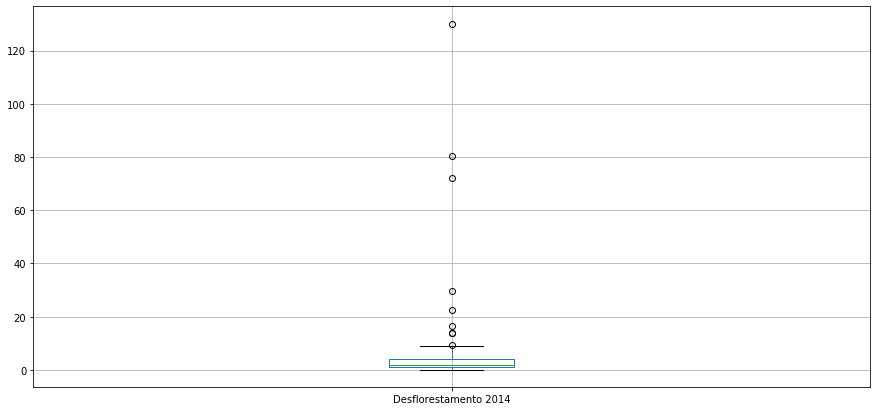

```python
merged_df.boxplot(column=['Desflorestamento 2014'], figsize=(15,7))
```

#### 1.2 Desflorestamento Relativo

Com intuito de comparar taxas de desflorestamento nos diferentes municípios criaremos a variável *Desflorestamento Relativo*. No escopo dessa análise o desflorestamento relativo é dado pelas colunas *Desflorestamento 2014* / *Floresta*, onde:

*Floresta* - área da floresta

```python
#calcula as informações do desflorestamento
merged_df['Desflorestamento Relativo'] = merged_df['Desflorestamento 2014']/merged_df['Floresta']

desfl_mean = merged_df['Desflorestamento Relativo'].mean()
desfl_min = merged_df['Desflorestamento Relativo'].min()
desfl_max = merged_df['Desflorestamento Relativo'].max()
```

Além disso, criaremos uma coluna indicará se um município possui *Desflorestamento Relativo Acima da Média*:

```python
merged_df['Desflorestamento Relativo Acima da Média'] = merged_df['Desflorestamento Relativo'].apply(lambda x: 1 if x > desfl_mean else 0)
```

```python
merged_df[['Municípios','Desflorestamento Relativo Acima da Média']].groupby('Desflorestamento Relativo Acima da Média').describe()
```

| Desflorestamento Relativo Acima da Média | Municípios count | Municípios unique | Municípios top | Municípios freq |
| --- | --- | --- | --- | --- |
| 0 | 46 | 46 | Maues | 1 |
| 1 | 16 | 16 | Canutama | 1 |

Visualizando o DataFrame com suas novas colunas:

```python
merged_df.head()
```

|  | Municípios | Agricultura Anual | Área não Observada | Área Urbana | Desflorestamento 2014 | Floresta | Hidrografia | Mineração | Mosaico de Ocupações | Não Floresta | ... | Vegetação Secundária | Total Geral | codigo_ibge | nome | latitude | longitude | capital | codigo_uf | Desflorestamento Relativo | Desflorestamento Relativo Acima da Média |
| --- | --- | --- | --- | --- | --- | --- | --- | --- | --- | --- | --- | --- | --- | --- | --- | --- | --- | --- | --- | --- | --- |
| 0 | Alvaraes | NaN | 0.07 | 1.90 | 2.75 | 5415.56 | 133.87 | NaN | 101.08 | 43.26 | ... | 198.55 | 5911.46 | 1300029 | Alvaraes | -3.22727 | -64.8007 | 0 | 13 | 0.000508 | 0 |
| 1 | Amatura | NaN | NaN | 2.05 | 0.36 | 4220.22 | 209.41 | NaN | 15.87 | 216.55 | ... | 71.74 | 4755.42 | 1300060 | Amatura | -3.37455 | -68.2005 | 0 | 13 | 0.000085 | 0 |
| 2 | Anama | NaN | 0.86 | 0.89 | 0.44 | 2001.85 | 229.30 | NaN | 6.90 | 34.81 | ... | 160.61 | 2451.66 | 1300086 | Anama | -3.56697 | -61.3963 | 0 | 13 | 0.000220 | 0 |
| 3 | Anori | NaN | 0.15 | 2.77 | 0.59 | 4646.53 | 436.07 | NaN | 17.12 | 636.01 | ... | 41.98 | 5794.49 | 1300102 | Anori | -3.74603 | -61.6575 | 0 | 13 | 0.000127 | 0 |
| 4 | Apui | NaN | 6.71 | 5.91 | 80.19 | 51396.43 | 213.50 | NaN | 8.76 | 622.87 | ... | 546.18 | 54238.32 | 1300144 | Apui | -7.19409 | -59.8960 | 0 | 13 | 0.001560 | 1 |

5 rows × 26 columns

Observando a distribuição dos valores do Desflorestamento Relativo

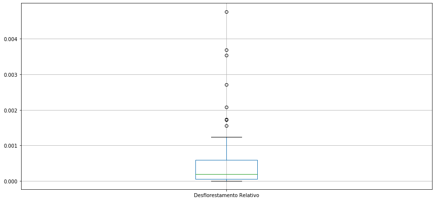

```python
merged_df.boxplot(column=['Desflorestamento Relativo'], figsize=(15,7))
```

Como é de se esperar o Desflorestamento Relativo possui menor variancia em relação ao Desflorestamento Absoluto.

#### 1.3 Desflorestamento Relativo por Municípios

```python
#codigo de plot
merged_df.plot.scatter(x='longitude',y='latitude',
                       s=merged_df['Floresta']/(merged_df['Floresta'].min()),
                       c='Desflorestamento Relativo', cmap='coolwarm', alpha=0.9,
                       figsize=(8,8))
# for lat,long in zip(merged_df.latitude, merged_df.longitude):
#     plt.scatter([long], [lat], marker='o', c='purple')

#transforma o plot em localizações no mapa
mplleaflet.display()
```

[interactive chart not shown]

No gráfico acima o tamanho dos marcadores representa o tamanho da *Floresta* ao passo que as cores indicam a instensidade do *Desflorestamento Relativo*.

#### 1.4 Desflorestamento Relativo Acima da Média por Municípios

```python
#codigo de plot
merged_df.plot.scatter(x='longitude',y='latitude',
                       s=merged_df['Floresta']/(merged_df['Floresta'].min()),
                       c='Desflorestamento Relativo Acima da Média', cmap='coolwarm', alpha=0.7,
                       figsize=(8,8))
# for lat,long in zip(merged_df.latitude, merged_df.longitude):
#     plt.scatter([long], [lat], marker='o', c='purple')

#transforma o plot em localizações no mapa
mplleaflet.display()
```

[interactive chart not shown]

No gráfico acima o tamanho dos marcadores representa o tamanho da *Floresta* ao passo que as cores indicam a instensidade do *Desflorestamento Relativo Acima da Média*. Nesse contexto, a cor vermelha indica que a Floresta possui desflorestamento acima da média.

## 2. Relação entre Mineração e Desmatamento (dados de 2014)

#### 2.1 Calculando relações entre desflorestamento e mineração

```python
merged_df[['Mineração', 'Desflorestamento Relativo']].corr()
```

|  | Mineração | Desflorestamento Relativo |
| --- | --- | --- |
| Mineração | 1.000000 | -0.219413 |
| Desflorestamento Relativo | -0.219413 | 1.000000 |

```python
merged_df[['Mineração', 'Desflorestamento Relativo Acima da Média' ]].corr()
```

|  | Mineração | Desflorestamento Relativo Acima da Média |
| --- | --- | --- |
| Mineração | 1.000000 | -0.122361 |
| Desflorestamento Relativo Acima da Média | -0.122361 | 1.000000 |

#### Observação 1: Correlação Negativa

A correlação negativa se dá quando $r < 0$, e nesse caso à medida que $x$ cresce, $y$ decresce (em média).

Em ambas tabelas acima que relacionam mineração e desflorestamento encontrou-se correlações negativas entre as colunas observadas.

```python
merged_df[['Mineração', 'Desflorestamento Relativo Acima da Média' ]]\
        .sort_values(by='Mineração', ascending=False)[:15]\
        .groupby('Desflorestamento Relativo Acima da Média').describe()
```

| Desflorestamento Relativo Acima da Média | Mineração count | Mineração mean | Mineração std | Mineração min | Mineração 25% | Mineração 50% | Mineração 75% | Mineração max |
| --- | --- | --- | --- | --- | --- | --- | --- | --- |
| 0 | 8.0 | 3.48625 | 5.844211 | 0.01 | 0.1075 | 1.18 | 3.010 | 16.89 |
| 1 | 7.0 | 2.33000 | 3.857594 | 0.03 | 0.2100 | 0.86 | 2.075 | 10.85 |

#### Observação 2: Distribuição Mineração vs Desflorestamento Relativo Acima da Média

A distribuição é bastante parelha (8x7) e não permite inferir que a mineração provoque desflorestamento acima da média.

#### 2.2 Distribuição dos valores da coluna Mineração

```python
merged_df['Mineração'].count()
```

```
15
```

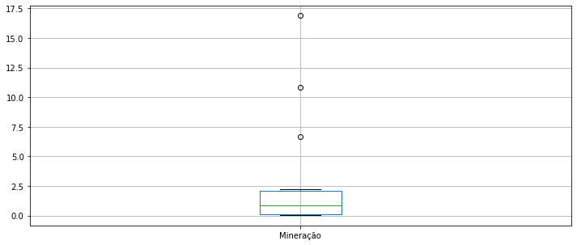

```python
merged_df.boxplot(column=['Mineração'], figsize=(12,5))
```

#### Observação 3: Poucos valores de mineração

Podemos observar que apenas quinze(de sessenta e dois) valores não são **NaN** e desses quinze, três destoam da média. A ausência de informação alcança 75,8% do conjunto de dados.

#### 2.3 Distribuição dos valores da coluna Mineração vs. Desflorestamento Relativo

Agrupando os dados por *Mineração*:

```python
merged_df[['Municípios', 'Mineração', 'Desflorestamento Relativo',
           'Desflorestamento Relativo Acima da Média' ]]\
        .sort_values(by='Mineração', ascending=False)
```

|  | Municípios | Mineração | Desflorestamento Relativo | Desflorestamento Relativo Acima da Média |
| --- | --- | --- | --- | --- |
| 37 | Manaus | 16.89 | 0.000245 | 0 |
| 44 | Novo Aripuana | 10.85 | 0.000596 | 1 |
| 40 | Maues | 6.70 | 0.000380 | 0 |
| 34 | Labrea | 2.25 | 0.002081 | 1 |
| 12 | Boca do Acre | 1.90 | 0.003682 | 1 |
| 60 | Urucara | 1.78 | 0.000055 | 0 |
| 47 | Presidente Figueiredo | 1.48 | 0.000292 | 0 |
| 48 | Rio Preto da Eva | 0.88 | 0.000212 | 0 |
| 35 | Manacapuru | 0.86 | 0.000702 | 1 |
| 27 | Iranduba | 0.39 | 0.001729 | 1 |
| 53 | Sao Sebastiao do Uatuma | 0.14 | 0.000385 | 0 |
| 28 | Itacoatiara | 0.03 | 0.001193 | 1 |
| 61 | Urucurituba | 0.03 | 0.004762 | 1 |
| 7 | Barcelos | 0.01 | 0.000019 | 0 |
| 14 | Caapiranga | 0.01 | 0.000088 | 0 |
| 0 | Alvaraes | NaN | 0.000508 | 0 |
| 1 | Amatura | NaN | 0.000085 | 0 |
| 2 | Anama | NaN | 0.000220 | 0 |
| 3 | Anori | NaN | 0.000127 | 0 |
| 4 | Apui | NaN | 0.001560 | 1 |
| 5 | Atalaia do Norte | NaN | 0.000009 | 0 |
| 6 | Autazes | NaN | 0.001716 | 1 |
| 8 | Barreirinha | NaN | 0.001237 | 1 |
| 9 | Benjamin Constant | NaN | 0.000037 | 0 |
| 10 | Beruri | NaN | 0.000147 | 0 |
| 11 | Boa Vista do Ramos | NaN | 0.000902 | 1 |
| 13 | Borba | NaN | 0.000035 | 0 |
| 15 | Canutama | NaN | 0.000604 | 1 |
| 16 | Carauari | NaN | 0.000042 | 0 |
| 17 | Careiro | NaN | 0.000115 | 0 |
| ... | ... | ... | ... | ... |
| 20 | Codajas | NaN | 0.000183 | 0 |
| 21 | Eirunepe | NaN | 0.000168 | 0 |
| 22 | Envira | NaN | 0.001039 | 1 |
| 23 | Fonte Boa | NaN | 0.000091 | 0 |
| 24 | Guajara | NaN | 0.000162 | 0 |
| 25 | Humaita | NaN | 0.000490 | 0 |
| 26 | Ipixuna | NaN | 0.000092 | 0 |
| 29 | Itamarati | NaN | 0.000099 | 0 |
| 30 | Itapiranga | NaN | 0.000215 | 0 |
| 31 | Japura | NaN | 0.000018 | 0 |
| 32 | Jurua | NaN | 0.000098 | 0 |
| 33 | Jutai | NaN | 0.000024 | 0 |
| 36 | Manaquiri | NaN | 0.000045 | 0 |
| 38 | Manicore | NaN | 0.000716 | 1 |
| 39 | Maraa | NaN | 0.000117 | 0 |
| 41 | Nhamunda | NaN | 0.000191 | 0 |
| 42 | Nova Olinda do Norte | NaN | 0.000255 | 0 |
| 43 | Novo Airao | NaN | 0.000024 | 0 |
| 45 | Parintins | NaN | 0.002704 | 1 |
| 46 | Pauini | NaN | 0.000230 | 0 |
| 49 | Santa Isabel do Rio Negro | NaN | 0.000015 | 0 |
| 50 | Santo Antonio do Ica | NaN | 0.000069 | 0 |
| 51 | Sao Gabriel da Cachoeira | NaN | 0.000017 | 0 |
| 52 | Sao Paulo de Olivenca | NaN | 0.000053 | 0 |
| 54 | Silves | NaN | 0.000209 | 0 |
| 55 | Tabatinga | NaN | 0.000571 | 0 |
| 56 | Tapaua | NaN | 0.000035 | 0 |
| 57 | Tefe | NaN | 0.000396 | 0 |
| 58 | Tonantins | NaN | 0.000060 | 0 |
| 59 | Uarini | NaN | 0.000366 | 0 |

62 rows × 4 columns

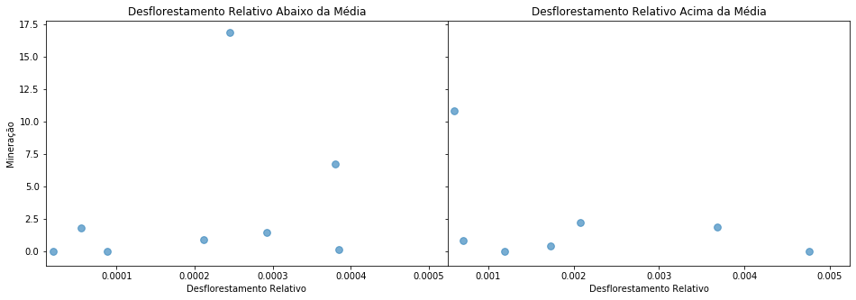

```python
fig, ax = plt.subplots(1,2, figsize=(16,5), sharey='all')
plt.subplots_adjust(wspace=0,hspace=0)

merged_df.sort_values(by='Desflorestamento Relativo', ascending=False)[16:]\
.plot.scatter('Desflorestamento Relativo', 'Mineração',
                       s=60, alpha=0.6,ax=ax[0],
                     xlim=(merged_df['Desflorestamento Relativo'].min(),
                           merged_df['Desflorestamento Relativo'].mean()-merged_df['Desflorestamento Relativo'].mean()/10),
             title='Desflorestamento Relativo Abaixo da Média')

merged_df.sort_values(by='Desflorestamento Relativo', ascending=False)[:16]\
.plot.scatter('Desflorestamento Relativo', 'Mineração',
                       s=60, alpha=0.6, ax=ax[1],
              xlim=(merged_df['Desflorestamento Relativo'].mean()-merged_df['Desflorestamento Relativo'].mean()/10,
                    merged_df['Desflorestamento Relativo'].max()+merged_df['Desflorestamento Relativo'].max()/10),
             title='Desflorestamento Relativo Acima da Média')
```

Podemos utilizar um mapa de cores para auxiliar na distinção dos valores de *Mineração*:

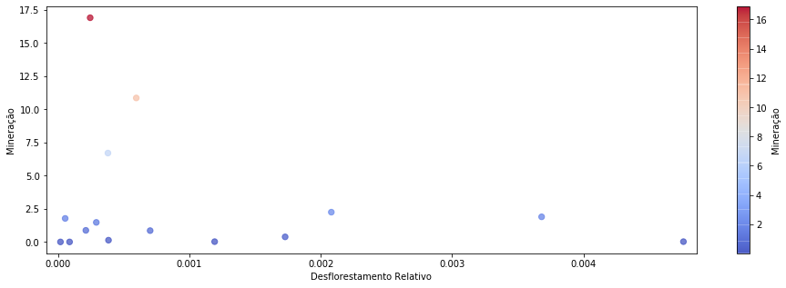

```python
fig, ax = plt.subplots(figsize=(16,5))
ax.set_xlabel('Desflorestamento Relativo')
merged_df.sort_values(by='Desflorestamento Relativo', ascending=False)\
.plot.scatter('Desflorestamento Relativo', 'Mineração',  s=40, alpha=0.7,
              xlim=(merged_df['Desflorestamento Relativo'].min()-0.0001,
                   merged_df['Desflorestamento Relativo'].max()+0.0001),
             c='Mineração', cmap='coolwarm', ax=ax)
```

#### Observação 4: Nenhuma tendência relevante observada

Os gráficos de MineraçãoxDesflorestamento Relativo não indicam tendência de crescimento do desflorestamento com o crescimento da mineração.

E se olharmos apenas para os municípios que possuem *Desflorestamento Relativo Acima da Média*?

#### 2.4 Distribuição dos valores da coluna Mineração vs. Desflorestamento Relativo Acima da Média

```python
merged_df[merged_df['Desflorestamento Relativo Acima da Média']>0].count()['Desflorestamento Relativo Acima da Média']
```

```
16
```

```python
merged_df[['Municípios', 'Mineração', 'Desflorestamento Relativo',
           'Desflorestamento Relativo Acima da Média' ]]\
.sort_values(by='Desflorestamento Relativo', ascending=False)[:15]
```

|  | Municípios | Mineração | Desflorestamento Relativo | Desflorestamento Relativo Acima da Média |
| --- | --- | --- | --- | --- |
| 61 | Urucurituba | 0.03 | 0.004762 | 1 |
| 12 | Boca do Acre | 1.90 | 0.003682 | 1 |
| 18 | Careiro da Varzea | NaN | 0.003537 | 1 |
| 45 | Parintins | NaN | 0.002704 | 1 |
| 34 | Labrea | 2.25 | 0.002081 | 1 |
| 27 | Iranduba | 0.39 | 0.001729 | 1 |
| 6 | Autazes | NaN | 0.001716 | 1 |
| 4 | Apui | NaN | 0.001560 | 1 |
| 8 | Barreirinha | NaN | 0.001237 | 1 |
| 28 | Itacoatiara | 0.03 | 0.001193 | 1 |
| 22 | Envira | NaN | 0.001039 | 1 |
| 11 | Boa Vista do Ramos | NaN | 0.000902 | 1 |
| 38 | Manicore | NaN | 0.000716 | 1 |
| 35 | Manacapuru | 0.86 | 0.000702 | 1 |
| 15 | Canutama | NaN | 0.000604 | 1 |

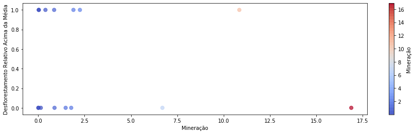

```python
fig, ax = plt.subplots(figsize=(15,4))
ax.set_xlabel('Mineração')
merged_df.plot.scatter('Mineração', 'Desflorestamento Relativo Acima da Média',
                       s=50, alpha=0.7, ax=ax,
                       c='Mineração', cmap='coolwarm')
```

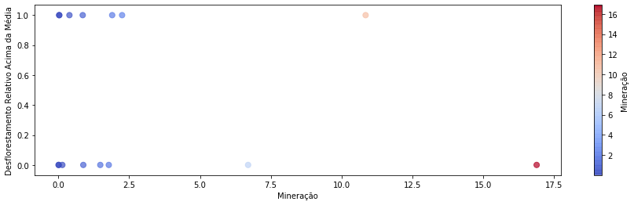

```python
fig, ax = plt.subplots(figsize=(15,4))
ax.set_xlabel('Mineração')
merged_df.plot.scatter('Mineração', 'Desflorestamento Relativo Acima da Média',
                       s=50, alpha=0.7, ax=ax,
                       c='Mineração', cmap='coolwarm')
```

#### Observação 5:

Observamos nos dois gráficos acima que não a relação de causa e efeito entre mineração e desflorestamento acima da média nos municípios do Amazonas.

#### 2.5 Mineração por Municípios

```python
# conclusoes sobre mineração e desflorestamento
merged_df.plot.scatter(x='longitude',y='latitude',
                       s=merged_df['Mineração'].dropna()/merged_df['Mineração'].dropna().min(),
                       c='sienna', alpha=0.8, figsize=(8,8))
mplleaflet.display()
```

[interactive chart not shown]

No gráfico acima atribuímos o tamanho do marcador de acordo com a intensidade da mineração no município.

#### 2.6 Mineração vs. Desflorestamento Acima da Média por Muicípios

E se visualizarmos minerção e desflorestamento relativo em um único mapa?

```python
#codigo de plot

fig, ax = plt.subplots(figsize=(6,8))
merged_df.plot.scatter(x='longitude',y='latitude',
                       s=merged_df['Floresta']/(merged_df['Floresta'].min()),
                       c='Desflorestamento Relativo Acima da Média', cmap='coolwarm', alpha=0.8,
                       ax=ax)

merged_df.plot.scatter(x='longitude',y='latitude',
                       s=merged_df['Mineração'].dropna()/merged_df['Mineração'].dropna().min(),
                       c='sienna', alpha=0.8, ax=ax)

mplleaflet.display()
```

[interactive chart not shown]

#### Observação 6

Analisando o mapa comparativo também não se observa nenhuma tendência relevante entre mineração e desflorestamento relativo acima da média.

## Conclusão

Aqui reuni-se o conjunto de observações extraídas no processo de análise dos dados de desflorestamento e mineração de 2014.

**Observação 1 - Correlação Negativa:** A correlação negativa se dá quando $r < 0$, e nesse caso à medida que $x$ cresce, $y$ decresce (em média).

Em ambas tabelas acima que relacionam mineração e desflorestamento encontrou-se correlações negativas entre as colunas observadas.

**Observação 2 - Distribuição Mineração vs Desflorestamento Relativo Acima da Média:**  
A distribuição é bastante parelha (8x7) e não permite inferir que a mineração provoque desflorestamento acima da média.

**Observação 3 - Poucos valores de mineração:** Podemos observar que apenas quinze(de sessenta e dois) valores não são **NaN** e desses quinze, três destoam da média. A ausência de informação alcança 75,8% do conjunto de dados.

**Observação 4 - Nenhuma tendência relevante observada:** Os gráficos de MineraçãoxDesflorestamento Relativo não indicam tendência de crescimento do desflorestamento com o crescimento da mineração.

**Observação 5:** Observamos nos dois gráficos acima que não a relação de causa e efeito entre mineração e desflorestamento acima da média nos municípios do Amazonas.

**Observação 6:** Analisando o mapa comparativo também não se observa nenhuma tendência relevante entre mineração e desflorestamento relativo acima da média.